# 02 · Differential expression

## Load packages

```r
pacman::p_load(here, limpa, limma, dplyr, ggplot2, purrr, tibble, tidyr, writexl)
here::i_am("02_Differential_Expression/02_Differential/a_script/02_differential.qmd")
```

## Read proteins and design

```r
quant <- here("01_Preprocess", "02_Quantification", "c_data")
proteins <- readRDS(file.path(quant, "proteins.rds"))
d <- readRDS(here("02_Differential_Expression", "01_Design", "c_data", "design.rds"))
stopifnot(identical(rownames(d$design), colnames(proteins$E)))
```

## Fit

`dpcDE()` replaces `lmFit()` because only it reads the `dpcQuant()` standard errors, and `robust = TRUE` keeps outlying variances from distorting the prior. Sample quality weights are off (limpa’s default): estimated, they did not follow contaminant load.

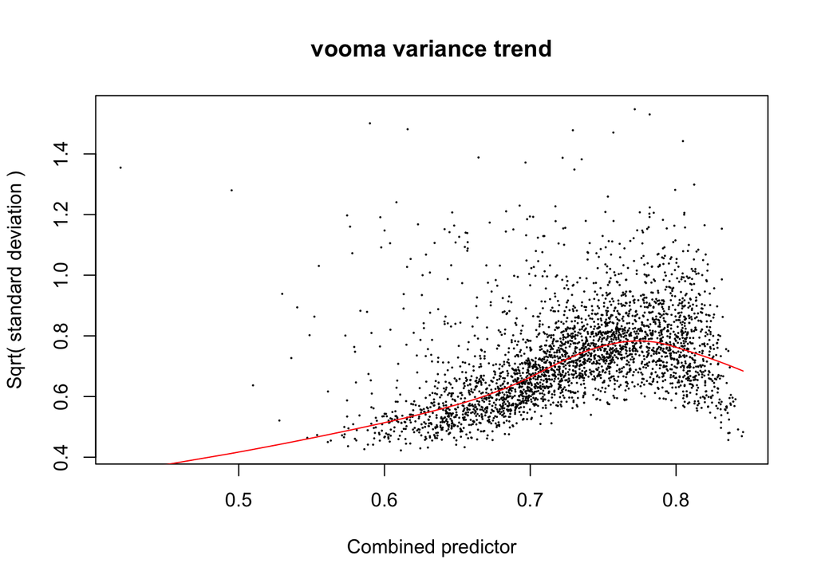

```r
coefficient_fit <- dpcDE(proteins, d$design)
```

```r
# The blood slope is log2 protein per log2 haemoglobin, near 1 for a protein only blood carries.
blood_fit <- eBayes(coefficient_fit, robust = TRUE) |>
  topTable(coef = "blood", number = Inf, sort.by = "none")
fit <- eBayes(contrasts.fit(coefficient_fit, d$contrasts), robust = TRUE)
sum(blood_fit$adj.P.Val < 0.05)
```

```
[1] 951
```

## Results

Benjamini-Hochberg (BH) adjustment runs within each contrast, because each answers its own question.

```r
results <- map(colnames(d$contrasts), function(cn) {
  topTable(fit, coef = cn, number = Inf, sort.by = "none") |>
    rownames_to_column("protein") |>
    mutate(contrast = cn, .before = 1)
}) |>
  list_rbind()

contrast_summary <- results |>
  summarise(
    n_tested = n(),
    n_fdr_05 = sum(adj.P.Val < 0.05),
    n_fdr_10 = sum(adj.P.Val < 0.10),
    min_adj_p = min(adj.P.Val),
    .by = contrast
  )
contrast_summary |>
  mutate(min_adj_p = signif(min_adj_p, 3))
```

```
                     contrast n_tested n_fdr_05 n_fdr_10 min_adj_p
1                BFR_Post-Pre     3042       95      170  1.52e-04
2               HLRT_Post-Pre     3042      218      332  2.16e-10
3            BFR_Pre-HLRT_Pre     3042        0        0  4.21e-01
4          BFR_Post-HLRT_Post     3042        0        0  4.53e-01
5 Modality_x_Time_Interaction     3042        0        0  6.82e-01
```

## Inspect p-value distributions

A skewed histogram would show miscalibration before any hit is trusted; under a flat null, 20% of p fall below 0.2 and the median |t| is about 0.67.

```r
results |>
  summarise(
    prop_true_null = round(propTrueNull(P.Value), 3),
    median_abs_t = round(median(abs(t)), 3),
    p_below_0.2 = round(mean(P.Value < 0.2), 3), .by = contrast
  )
```

```
                     contrast prop_true_null median_abs_t p_below_0.2
1                BFR_Post-Pre          0.797        0.932       0.349
2               HLRT_Post-Pre          0.733        1.041       0.417
3            BFR_Pre-HLRT_Pre          0.957        0.733       0.234
4          BFR_Post-HLRT_Post          0.970        0.718       0.224
5 Modality_x_Time_Interaction          0.999        0.671       0.191
```

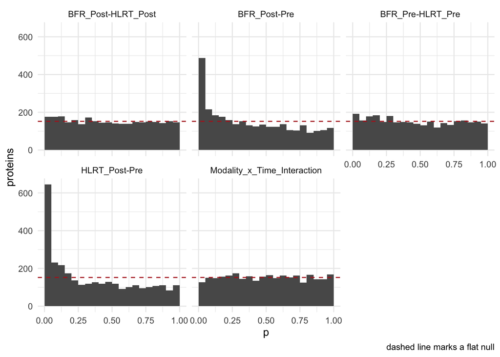

```r
ggplot(results, aes(P.Value)) +
  geom_histogram(binwidth = 0.05, boundary = 0, fill = "grey35") +
  geom_hline(yintercept = nrow(proteins) / 20, linetype = 2, colour = "firebrick") +
  facet_wrap(~contrast) +
  labs(x = "p", y = "proteins", caption = "dashed line marks a flat null") +
  theme_minimal()
```

```r
# log2 interaction effect for 80% power at unadjusted 0.05: sensitivity, not FDR-adjusted power.
se <- fit$stdev.unscaled[, "Modality_x_Time_Interaction"] * sqrt(fit$s2.post)
round(quantile(se * (qt(0.975, fit$df.total) + qt(0.80, fit$df.total)), c(0.5, 0.9)), 3)
```

```
  50%   90%
0.490 0.824
```

## The pi score

`pi_score` (`P.Value^abs(logFC)`) orders proteins as Xiao et al.’s π does (2014, doi:10.1093/bioinformatics/btr671); it ranks, controls no error rate and selects nothing. Mean observations sit beside it, because the top of a π ranking is often thinly observed.

```r
results |>
  filter(contrast %in% c("BFR_Post-Pre", "HLRT_Post-Pre")) |>
  mutate(pi_score = P.Value^abs(logFC)) |>
  slice_min(pi_score, n = 10, by = contrast) |>
  mutate(mean_obs = round(rowMeans(proteins$other$n.observations)[protein], 2)) |>
  select(contrast, protein, Genes, logFC, adj.P.Val, pi_score, NPrec, mean_obs)
```

```
        contrast protein   Genes      logFC    adj.P.Val     pi_score NPrec
1   BFR_Post-Pre  P09455    RBP1  1.4555245 9.442357e-04 8.657833e-09    10
2   BFR_Post-Pre  Q9ULX7    CA14  0.9458901 6.845798e-04 3.245960e-06     3
3   BFR_Post-Pre  P43490   NAMPT  0.6875244 1.521959e-04 9.562067e-06    29
4   BFR_Post-Pre  Q9H1R3   MYLK2 -0.5048437 2.477013e-04 3.741273e-04    37
5   BFR_Post-Pre  A8MU46  SMTNL1 -0.6216088 1.997608e-03 7.724667e-04    40
6   BFR_Post-Pre  Q99584 S100A13  0.7836804 1.146738e-02 1.029762e-03     7
7   BFR_Post-Pre  O43837   IDH3B  0.4827463 4.897709e-04 1.159690e-03    31
8   BFR_Post-Pre  A5YM72  CARNS1  0.6306255 3.704115e-03 1.192878e-03    25
9   BFR_Post-Pre  P04216    THY1  0.9050885 4.524850e-02 2.508407e-03     6
10  BFR_Post-Pre  P51553   IDH3G  0.4198162 4.897709e-04 2.984003e-03    21
11 HLRT_Post-Pre  P43490   NAMPT  1.0127337 2.160782e-10 4.830841e-14    29
12 HLRT_Post-Pre  P30837 ALDH1B1  0.9691706 9.807035e-10 1.531926e-12    33
13 HLRT_Post-Pre  P04216    THY1  1.6152036 1.499579e-05 1.575436e-12     6
14 HLRT_Post-Pre  Q9ULX7    CA14  1.2353763 5.854816e-07 9.095583e-12     3
```

[output cut: 27 more lines]

## Baseline comparison

Counterbalanced legs before training should differ by nothing, so hits here would point to a problem upstream.

```r
results |>
  filter(contrast == d$baseline) |>
  slice_min(P.Value, n = 5) |>
  select(protein, Genes, logFC, P.Value, adj.P.Val)
```

```
  protein  Genes      logFC      P.Value adj.P.Val
1  Q0D2K2 KLHL30 -0.3751254 0.0001554720 0.4210806
2  Q8NFV4 ABHD11  0.5796381 0.0003080552 0.4210806
3  Q12907  LMAN2  0.6015859 0.0004152669 0.4210806
4  Q9P0I2   EMC3 -0.4339701 0.0006472712 0.4555268
5  Q15181   PPA1  0.2820462 0.0009157092 0.4555268
```

## Without the blood covariate

Refitting without the blood index shows how much the covariate moves the discoveries.

```r
unadjusted_design <- d$design[, colnames(d$design) != "blood"]
unadjusted <- dpcDE(proteins, unadjusted_design, plot = FALSE) |>
  contrasts.fit(d$contrasts[colnames(unadjusted_design), ]) |>
  eBayes(robust = TRUE)
primary_hits <- decideTests(fit) != 0
unadjusted_hits <- decideTests(unadjusted) != 0
contrast_summary$n_fdr_05_unadjusted <- colSums(unadjusted_hits)[contrast_summary$contrast]
rbind(
  blood_adjusted = colSums(primary_hits),
  unadjusted = colSums(unadjusted_hits),
  both = colSums(primary_hits & unadjusted_hits)
)
```

```
               BFR_Post-Pre HLRT_Post-Pre BFR_Pre-HLRT_Pre BFR_Post-HLRT_Post
blood_adjusted           95           218                0                  0
unadjusted               86           161                0                  0
both                     86           153                0                  0
               Modality_x_Time_Interaction
blood_adjusted                           0
unadjusted                               0
both                                     0
```

## Slope sensitivity

The preset slope of 0.7 is a choice, so the fitted-slope run, when it exists, goes through the same filter, normalisation and design.

```r
fitted_slope <- readRDS(file.path(quant, "quant_runs", "proteins_slope_fitted.rds"))
fitted_slope <- fitted_slope[
  filterByDetection(fitted_slope, n.samples = min(table(fitted_slope$targets$group))),
]
fitted_slope$E <- normalizeBetweenArrays(fitted_slope$E, method = "cyclicloess")
stopifnot(identical(colnames(fitted_slope$E), rownames(d$design)))
refit <- dpcDE(fitted_slope, d$design, plot = FALSE) |>
  contrasts.fit(d$contrasts) |>
  eBayes(robust = TRUE)
refit_hits <- decideTests(refit)[rownames(primary_hits), , drop = FALSE] != 0
rbind(
  slope_0.7 = colSums(primary_hits),
  fitted_curve = colSums(refit_hits),
  both = colSums(primary_hits & refit_hits)
)
```

```
             BFR_Post-Pre HLRT_Post-Pre BFR_Pre-HLRT_Pre BFR_Post-HLRT_Post
slope_0.7              95           218                0                  0
fitted_curve          100           221                0                  0
both                   84           200                0                  0
             Modality_x_Time_Interaction
slope_0.7                              0
fitted_curve                           0
both                                   0
```

## Save results

```r
protein_results <- results |>
  select(protein, Genes, NPrec, contrast, logFC, P.Value, adj.P.Val) |>
  pivot_wider(
    names_from = contrast,
    values_from = c(logFC, P.Value, adj.P.Val),
    names_glue = "{contrast}_{.value}"
  ) |>
  mutate(
    blood_slope = blood_fit[protein, "logFC"],
    blood_adj.P.Val = blood_fit[protein, "adj.P.Val"]
  )

out <- here("02_Differential_Expression", "02_Differential", "c_data")
saveRDS(fit, file.path(out, "fit.rds"))
write_xlsx(
  list(
    protein_results = protein_results,
    contrast_summary = contrast_summary
  ),
  file.path(out, "02_differential.xlsx")
)
```